# Credit Card Default: Machine Learning Tools

## 4.6 Explainability with SHAP

Neural networks are often criticised as black boxes. **SHAP** (SHapley Additive exPlanations) provides a principled, game-theoretic attribution of each feature’s contribution to a specific prediction. For PyTorch models, `shap.GradientExplainer` uses **integrated gradients**: it linearly interpolates each input from a background (reference) value to the actual value and accumulates gradients along the path, producing an attribution that satisfies the *efficiency* and *symmetry* axioms of Shapley values.

```python
import shap

mlp_final.eval()

# GradientExplainer requires the model to return a 2-D tensor (B, n_outputs).
# Our forward() squeezes to (B,), so we wrap it to restore the trailing dim.
class _SHAPWrapper(nn.Module):
    def __init__(self, model):
        super().__init__()
        self.model = model
    def forward(self, x):
        return self.model(x).unsqueeze(1)   # (B,) → (B, 1)

shap_model = _SHAPWrapper(mlp_final).to(device)
shap_model.eval()

# Background: 500-row training sample (reference distribution)
bg_tensor = torch.tensor(
    X_train_scaled.sample(500, random_state=42).values,
    dtype=torch.float32
).to(device)

# Test observations to explain
n_explain   = 1000
X_exp_np    = X_test_scaled.values[:n_explain]
X_exp_t     = torch.tensor(X_exp_np, dtype=torch.float32).to(device)

explainer    = shap.GradientExplainer(shap_model, bg_tensor)
shap_values  = explainer.shap_values(X_exp_t)

# GradientExplainer returns a list with one array per output
if isinstance(shap_values, list):
    shap_arr = shap_values[0]
else:
    shap_arr = shap_values
shap_arr = np.squeeze(shap_arr)   # ensure (n_explain, n_features) — drops trailing dim from wrapper

print(f"SHAP values shape: {shap_arr.shape}")
print(f"Explained observations: {n_explain} test samples")
```

```
SHAP values shape: (1000, 24)
Explained observations: 1000 test samples
```

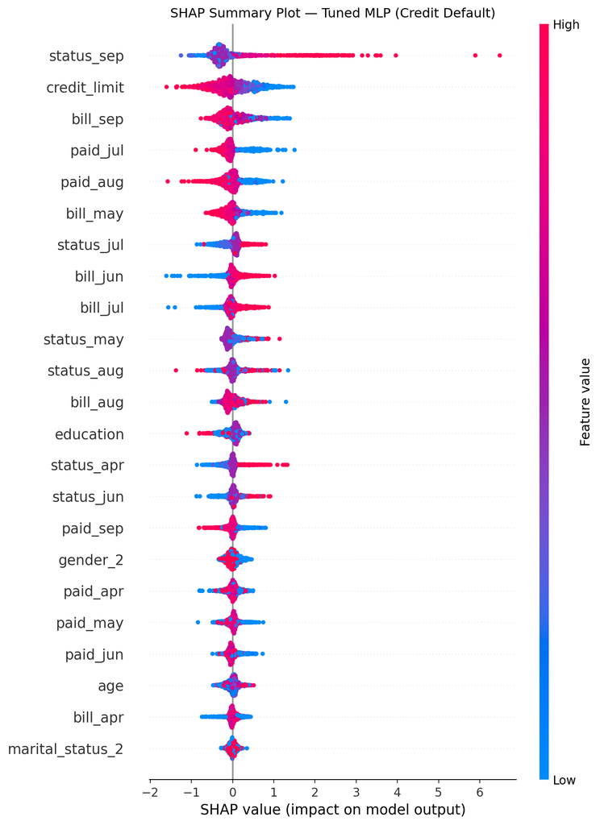

```python
# Beeswarm summary plot: SHAP value vs feature value for every observation
shap.summary_plot(
    shap_arr,
    features=X_exp_np,
    feature_names=X_test_scaled.columns.tolist(),
    plot_type='dot',
    show=False,
    max_display=23,
)
plt.title('SHAP Summary Plot — Tuned MLP (Credit Default)')
plt.tight_layout()
plt.show()
```

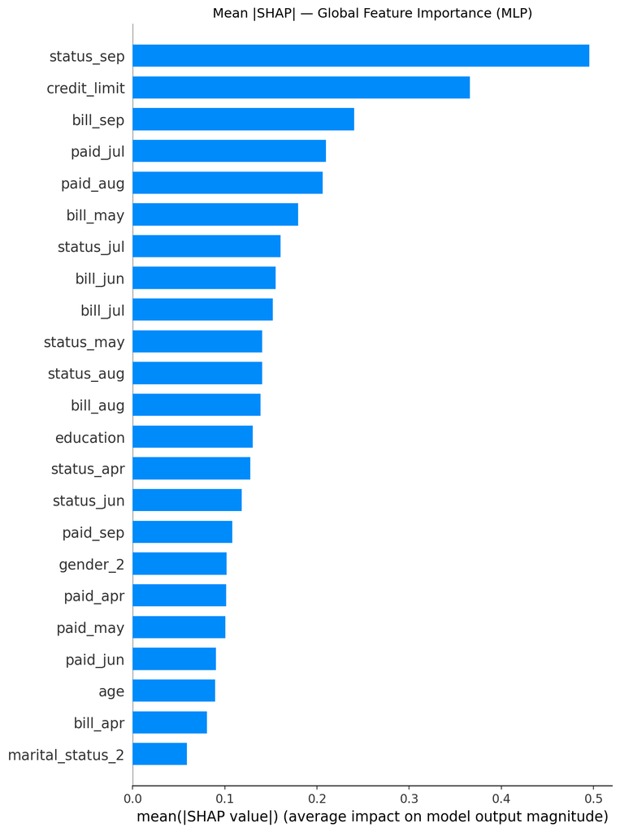

```python
# Global feature importance: mean |SHAP| per feature
shap.summary_plot(
    shap_arr,
    features=X_exp_np,
    feature_names=X_test_scaled.columns.tolist(),
    plot_type='bar',
    show=False,
    max_display=23,
)
plt.title('Mean |SHAP| — Global Feature Importance (MLP)')
plt.tight_layout()
plt.show()
```

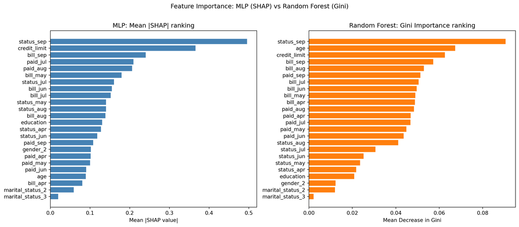

```python
# Cross-check: MLP SHAP importance vs Random Forest feature importance
mean_shap = np.abs(shap_arr).mean(axis=0)
shap_rank = pd.DataFrame({
    'Feature':   X_test_scaled.columns,
    'Mean |SHAP|': mean_shap,
    'RF Gini':   rf_best.feature_importances_,
}).sort_values('Mean |SHAP|', ascending=False)

fig, axes = plt.subplots(1, 2, figsize=(14, 6))

axes[0].barh(shap_rank['Feature'][::-1], shap_rank['Mean |SHAP|'][::-1],
             color='steelblue')
axes[0].set_title('MLP: Mean |SHAP| ranking')
axes[0].set_xlabel('Mean |SHAP value|')

shap_rank_rf = shap_rank.sort_values('RF Gini', ascending=False)
axes[1].barh(shap_rank_rf['Feature'][::-1], shap_rank_rf['RF Gini'][::-1],
             color='tab:orange')
axes[1].set_title('Random Forest: Gini Importance ranking')
axes[1].set_xlabel('Mean Decrease in Gini')

plt.suptitle('Feature Importance: MLP (SHAP) vs Random Forest (Gini)', y=1.01)
plt.tight_layout()
plt.show()
```